# Perkenalan R

# Panduan Materi Pengantar Analisis Regresi dengan R Studio

### Pertemuan 1: Pengenalan Analisis Regresi dan R Studio

## **1. Pengenalan R**

R adalah bahasa pemrograman dan lingkungan komputasi untuk analisis data (manipulasi data), statistik (perhitungan), dan visualisasi. R tergolong bahasa pemrograman open source dengan analisis statistikanya berupa serangkaian steps yang hasilnya disimpan dalam suatu objek.

## **2. Tipe Data di R**

R memiliki berbagai tipe data:

### a. **Vector**

Vector adalah tipe paling sederhana dari tipe data berupa kumpulan elemen dengan tipe yang sama.

```r
angka <- c(1, 2, 3, 4)
angka
```

```
## [1] 1 2 3 4
```

```r
teks <- c("A", "B", "C", "D")
teks
```

```
## [1] "A" "B" "C" "D"
```

```r
(logik <- c(TRUE, FALSE, TRUE))
```

```
## [1]  TRUE FALSE  TRUE
```

```r
#bisa gunakan perintah tertentu
#rep(pengulangan)
rep(angka,2)
```

```
## [1] 1 2 3 4 1 2 3 4
```

```r
rep(angka,each=2)
```

```
## [1] 1 1 2 2 3 3 4 4
```

```r
#seq(membuat suatu urutan)
seq(from=3, to=1)
```

```
## [1] 3 2 1
```

```r
seq(from=1, to=2, by=0.5)
```

```
## [1] 1.0 1.5 2.0
```

```r
#dapat mengambil bagian tertentu
teks[2:3]
```

```
## [1] "B" "C"
```

```r
teks[c(1, 2)]
```

```
## [1] "A" "B"
```

```r
angka[angka<3]
```

```
## [1] 1 2
```

```r
teks[-3]
```

```
## [1] "A" "B" "D"
```

### b. **Matrix**

Matrix adalah kumpulan data dua dimensi dengan elemen bertipe sama, dapat dibuat dari vector

```r
mat <- matrix(1:6, nrow = 2)
mat
```

```
##      [,1] [,2] [,3]
## [1,]    1    3    5
## [2,]    2    4    6
```

```r
data <- matrix(c(1,2,1, 100,102,103), nrow = 2, ncol = 3, byrow = TRUE)
data
```

```
##      [,1] [,2] [,3]
## [1,]    1    2    1
## [2,]  100  102  103
```

```r
dim(mat) #ukuran matriks
```

```
## [1] 2 3
```

```r
rbind(mat,data) #menggabungkan matriks terhadap baris
```

```
##      [,1] [,2] [,3]
## [1,]    1    3    5
## [2,]    2    4    6
## [3,]    1    2    1
## [4,]  100  102  103
```

```r
cbind(mat,data) #menggabungkan matriks terhadap kolom
```

```
##      [,1] [,2] [,3] [,4] [,5] [,6]
## [1,]    1    3    5    1    2    1
## [2,]    2    4    6  100  102  103
```

```r
#dapat mengambil bagian tertentu
data[1,3]
```

```
## [1] 1
```

```r
data[,2]
```

```
## [1]   2 102
```

```r
data[-1,-2]
```

```
## [1] 100 103
```

### c. **Factor**

Factor adalah bentuk khusus dari vector dengan elemen kategorik dan memiliki level

```r
dt<-c("a","b","a","a","a","b")
as.factor(dt)
```

```
## [1] a b a a a b
## Levels: a b
```

```r
jk <- factor(c("L", "P", "P", "L"))
levels(jk)
```

```
## [1] "L" "P"
```

### d. **List**

List adalah kumpulan elemen yang bisa bertipe berbeda.

```r
list(angka, teks = teks, data)
```

```
## [[1]]
## [1] 1 2 3 4
##
## $teks
## [1] "A" "B" "C" "D"
##
## [[3]]
##      [,1] [,2] [,3]
## [1,]    1    2    1
## [2,]  100  102  103
```

### e. **Data Frame**

Data Frame adalah kumpulan data dua dimensi dengan elemen bertipe campuran yang merupakan bentuk khusus dari list untuk menyimpan data berbagai tipe dalam bentuk matriks

```r
data.frame(Nama = c("Andi", "Budi"), Umur = c(25, 30))
```

```
##   Nama Umur
## 1 Andi   25
## 2 Budi   30
```

```r
data.frame(Mahasiswa=c("Amir","Budi", "Citra"), JK=c("L","L","P") )
```

```
##   Mahasiswa JK
## 1      Amir  L
## 2      Budi  L
## 3     Citra  P
```

## **3. Membaca Data ke R**

R dapat membaca berbagai format file:

### a. **Excel**

Gunakan paket `readxl`.

```r
#install.packages("readxl")
library(readxl)
# Membaca file Excel
data_excel <- read_excel("D:\\My Documents\\Downloads\\Data-excel-pertemuan-1.xlsx")
```

```r
data_excel
```

```
## # A tibble: 10 × 4
##    Nama    `Jenis Kelamin` `Pendidikan Terakhir` Status
##    <chr>   <chr>           <chr>                 <chr>
##  1 Cika    Perempuan       S1                    Menikah
##  2 Joni    Laki-Laki       SMA                   Menikah
##  3 Dina    Perempuan       S2                    Belum Menikah
##  4 Dilan   Laki-Laki       S2                    Menikah
##  5 Jaya    Laki-Laki       SMP                   Belum Menikah
##  6 Yadi    Laki-Laki       SMA                   Belum Menikah
##  7 Siti    Perempuan       SMP                   Menikah
##  8 Munaroh Perempuan       SD                    Menikah
##  9 Boy     Laki-Laki       S1                    Menikah
## 10 Girl    Perempuan       S3                    Belum Menikah
```

### b. **CSV**

```r
# Membaca file CSV
data_csv <- read.csv("D:\\My Documents\\Downloads\\Data csv pertemuan 1.csv", sep = ";")
dataaa <- read.csv2("D:\\My Documents\\Downloads\\Data csv pertemuan 1.csv")
```

```r
data_csv
```

```
##       Nama Jenis.Kelamin Pendidikan.Terakhir        Status
## 1     Cika     Perempuan                  S1       Menikah
## 2     Joni     Laki-Laki                 SMA       Menikah
## 3     Dina     Perempuan                  S2 Belum Menikah
## 4    Dilan     Laki-Laki                  S2       Menikah
## 5     Jaya     Laki-Laki                 SMP Belum Menikah
## 6     Yadi     Laki-Laki                 SMA Belum Menikah
## 7     Siti     Perempuan                 SMP       Menikah
## 8  Munaroh     Perempuan                  SD       Menikah
## 9      Boy     Laki-Laki                  S1       Menikah
## 10    Girl     Perempuan                  S3 Belum Menikah
```

```r
dataaa
```

```
##       Nama Jenis.Kelamin Pendidikan.Terakhir        Status
## 1     Cika     Perempuan                  S1       Menikah
## 2     Joni     Laki-Laki                 SMA       Menikah
## 3     Dina     Perempuan                  S2 Belum Menikah
## 4    Dilan     Laki-Laki                  S2       Menikah
## 5     Jaya     Laki-Laki                 SMP Belum Menikah
## 6     Yadi     Laki-Laki                 SMA Belum Menikah
## 7     Siti     Perempuan                 SMP       Menikah
## 8  Munaroh     Perempuan                  SD       Menikah
## 9      Boy     Laki-Laki                  S1       Menikah
## 10    Girl     Perempuan                  S3 Belum Menikah
```

## **4. Manipulasi Data Frame**

### a. **Mengambil Peubah dari Data Frame**

Gunakan tanda `$` atau indeks.

```r
# Mengambil kolom Nama
#data_excel$Nama

# Mengambil kolom kedua
dataaa[,3:4]
```

```
##    Pendidikan.Terakhir        Status
## 1                   S1       Menikah
## 2                  SMA       Menikah
## 3                   S2 Belum Menikah
## 4                   S2       Menikah
## 5                  SMP Belum Menikah
## 6                  SMA Belum Menikah
## 7                  SMP       Menikah
## 8                   SD       Menikah
## 9                   S1       Menikah
## 10                  S3 Belum Menikah
```

### b. **Menggabungkan Peubah**

Gunakan fungsi `cbind()` untuk kolom atau `rbind()` untuk baris.

```r
# Menggabungkan dua kolom
kolom_baru <- c(100, 85)
data_baru <- cbind(data_excel, Skor = kolom_baru)
data_baru
```

```
##       Nama Jenis Kelamin Pendidikan Terakhir        Status Skor
## 1     Cika     Perempuan                  S1       Menikah  100
## 2     Joni     Laki-Laki                 SMA       Menikah   85
## 3     Dina     Perempuan                  S2 Belum Menikah  100
## 4    Dilan     Laki-Laki                  S2       Menikah   85
## 5     Jaya     Laki-Laki                 SMP Belum Menikah  100
## 6     Yadi     Laki-Laki                 SMA Belum Menikah   85
## 7     Siti     Perempuan                 SMP       Menikah  100
## 8  Munaroh     Perempuan                  SD       Menikah   85
## 9      Boy     Laki-Laki                  S1       Menikah  100
## 10    Girl     Perempuan                  S3 Belum Menikah   85
```

## **5. Menyimpan Data dari R**

R dapat menyimpan data dalam berbagai format:

### a. **Excel**

Gunakan paket `writexl`.

```r
# Install dan load paket
#install.packages("writexl")
library(writexl)
# Menyimpan data ke file Excel
write_xlsx(data_baru, "data.xlsx")
```

### b. **CSV**

```r
# Menyimpan data ke file CSV
write.csv(data_excel, "data.csv", row.names = FALSE)
```

## **6. Paket untuk Analisis Regresi**

Beberapa paket populer: - **`stats`**: Paket bawaan R untuk regresi linear. - **`car`**: Menyediakan tools untuk diagnosa model. - **`lmtest`**: Untuk uji asumsi regresi.

## **7. Menghitung Korelasi**

### Syntax Dasar

Gunakan fungsi `cor()`.

```r
# Menghitung korelasi antara dua variabel
harga <- c(245, 312, 279, 308, 199, 219, 405, 324, 319, 255)
luas <- c(1400, 1600, 1700, 1875, 1100, 1550, 2350, 2450, 1425, 1700)
data_rumah <- data.frame(harga, luas)

cor(luas, harga)
```

```
## [1] 0.7621137
```

```r
(korelasi <- cor(data_rumah))
```

```
##           harga      luas
## harga 1.0000000 0.7621137
## luas  0.7621137 1.0000000
```

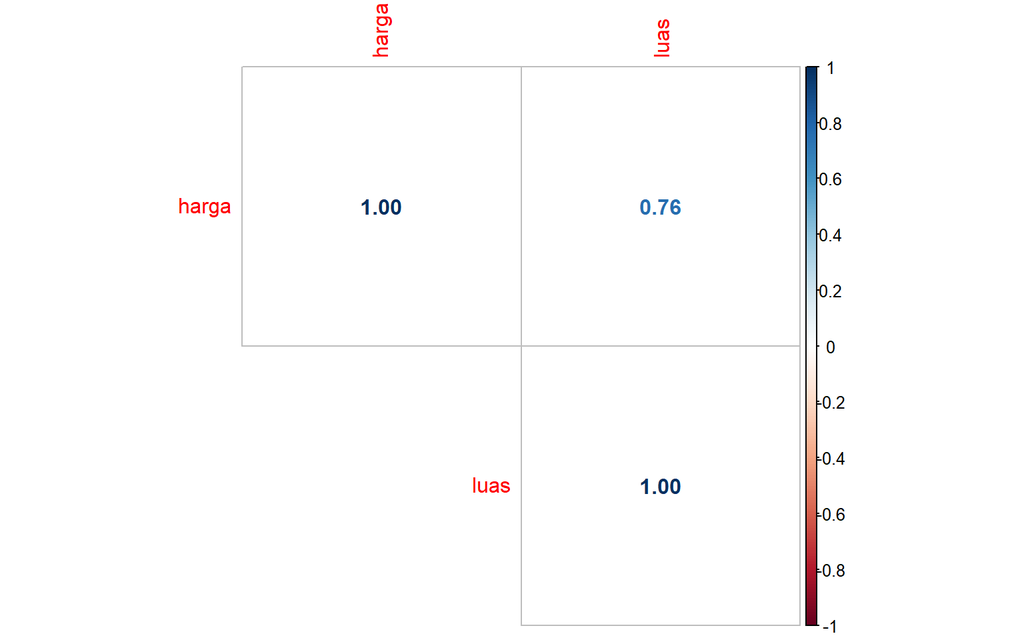

```r
library(corrplot)
corrplot(corr = korelasi, method = "number", type =
"upper")
```

```r
#uji signifikansi koefisien korelasi
cor.test(x = luas, y = harga, alternative = "two.sided", method = "pearson", exact = NULL, conf.level = 0.95)
```

```
##
##  Pearson's product-moment correlation
##
## data:  luas and harga
## t = 3.3294, df = 8, p-value = 0.01039
## alternative hypothesis: true correlation is not equal to 0
## 95 percent confidence interval:
##  0.2547085 0.9404622
## sample estimates:
##       cor
## 0.7621137
```

### Contoh dengan Dataset Built-in

```r
# Korelasi antara mpg dan hp di dataset mtcars
cor(mtcars$mpg, mtcars$hp)
```

```
## [1] -0.7761684
```

## **8. Membuat Scatter Plot**

Gunakan fungsi `plot()` untuk membuat scatter plot.

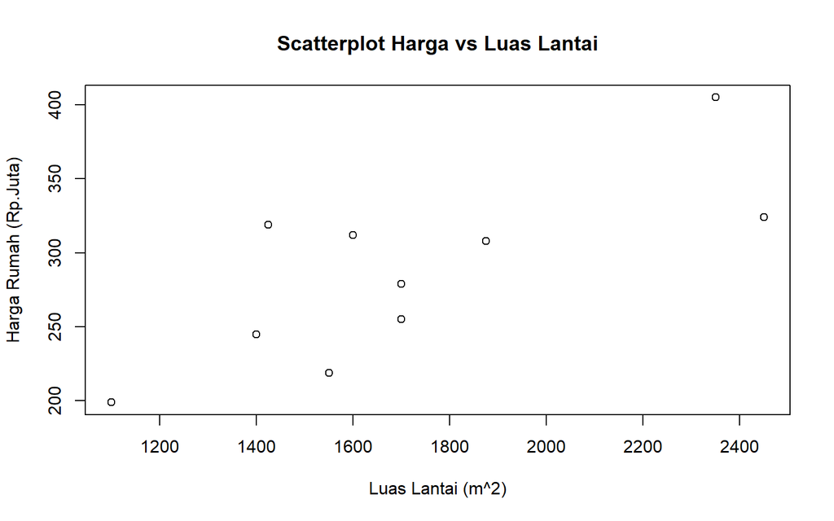

```r
# Membuat scatter plot
plot (x = luas, y = harga,
      main = "Scatterplot Harga vs Luas Lantai",
      xlab = "Luas Lantai (m^2)",
      ylab = "Harga Rumah (Rp.Juta)"
      )
```

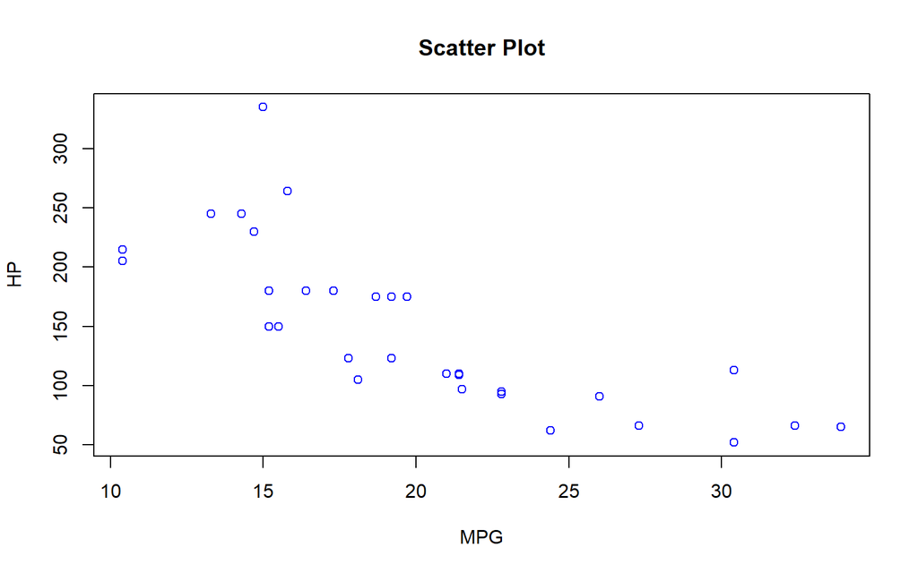

```r
plot(mtcars$mpg, mtcars$hp,
     main = "Scatter Plot",
     xlab = "MPG", ylab = "HP", col = "blue")
```

### Menambahkan Garis Tren

Gunakan fungsi `abline()`.

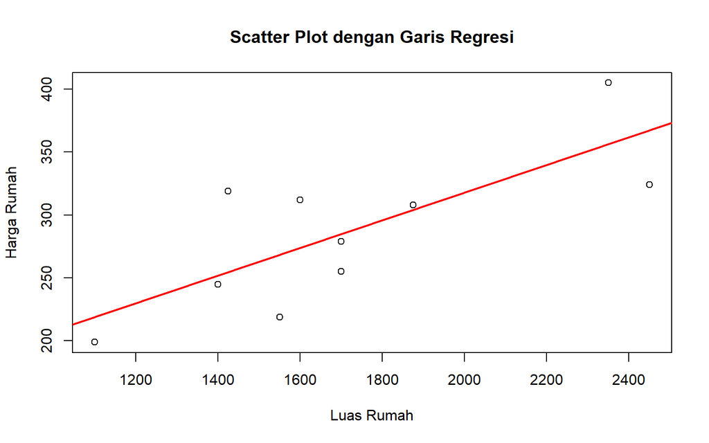

```r
plot(data_rumah$luas, data_rumah$harga,
     main = "Scatter Plot dengan Garis Regresi",
     xlab = "Luas Rumah",
     ylab = "Harga Rumah")

model <- lm(harga ~ luas, data = data_rumah)

abline(model, col = "red", lwd = 2)
```